# Sample Code for Performing Per Pixel Analysis

In the Helper Function section, I have three functions that perform the bulk of the fitting and calculations. They were designed with assumption that

1. Data is in MATLAB `.mat` form
2. All of the captures for a single exposure time is aggregated into a single 3D matrix of dimensions (number of captures per exposure x height of image x width of image)
3. There is a 1:1 mapping between exposure time and filename (the exposure time is stored in the filename of the file containing the 3D matrix)

If we want to adapt this to a new set of data, the following changes will have to be made:

1. The way data is read in the function `per_pixel_stats`. Instead of `loadmat` we might have to use another function
2. Add a preprocessing function that aggregates all of the captures for a single exposure time is aggregated into a single 3D matrix

Overall, changes only have to be made in the first steps of reading in data. As long as the input types are satisfied, the fits should work accordingly. The bulk of my time was spent tuning the fits (tolerance, initial guesses) to something that could be generalized for all taps.

## Setting up the notebook

```python
%matplotlib inline

import glob
import random
import numpy as np
import pandas as pd
from scipy.io import loadmat
from google.colab import drive
import matplotlib.pyplot as plt
from matplotlib.pyplot import imshow
from scipy.optimize import curve_fit
```

```python
drive.mount("/content/drive")
```

```python
# path of directory containing images
DIR = "/content/drive/My Drive/MS in CS/sun/20201108_matlab/mask1_tap1/"
```

```python
# List of filenames in sorted order, smallest to largest exposure time
fnames = glob.glob(DIR + '/*.mat')
fnames.sort()
filenames = [f.split('/')[-1].replace('.mat', '') for f in fnames]
```

```python
# The convention I had with Rahul was that there is a 1:1 mapping
# between exposure time and filename
exposures = np.array([float(f)/1e6 for f in filenames])
```

```python
# The dimesions of the input data were previously determined to be 320 x 648
WIDTH = 648
HEIGHT = 320
```

```python
# Region of interest: the left tap
X = 319
Y = 219
```

## Helper Functions

```python
def per_pixel_stats(path, filenames, height, width):
  """
  Returns per pixel mean, std and variance given 3D matrices
  (number of images captured per exposure x height x width)
  for a list of exposure times

  Assumes:
  1. exposure times and filenames of 3D matrices are 1:1 mappings
  2. input data is in MATLAB .mat format

  Parameters:
      path (string): directory containing data
      filenames (list of strings): list of filenames -- one filename per exposure
      height (int): height of image in number of pixels
      width (int): width of image in number of pixels

  Returns:
      avg_m (ndarray): 2D matrix (number of exposures x width x height matrix)
                       of mean value per pixel
      std_m (ndarray): 2D matrix (number of exposures x width x height matrix)
                       of std value per pixel
      var_m (ndarray): 2D matrix (number of exposures x width x height matrix)
                       of variance per pixel
  """
  shape = (len(filenames), height, width)
  avg_m = np.zeros(shape).astype(np.float32)
  std_m = np.zeros(shape).astype(np.float32)
  var_m = np.zeros(shape).astype(np.float32)

  for i, f in enumerate(filenames):
    mat = loadmat(path+f)['allImgs'] # TODO: Needs to be modified based on input datatype
    mat[mat < 0] = 0 # Rahul says all negative values are just set to zero
    avg_m[i,:,:] = mat.mean(axis=0)
    std_m[i,:,:] = mat.std(axis=0)
    var_m[i,:,:] = np.square(mat.std(axis=0))

  return avg_m, std_m, var_m
```

```python
# Must feed in initial guesses -- should be tweaked per camera
systemMax 	= [200000,	6500,	0.4, 2500, 0.002, 1000]
systemMin		= [10000 ,	0,	  0.002, -50, 0, 0]
systemIC 		= [20000 ,	4500,	  0.05, 0, 0.0008, 200]

def systemModel(t, gain_dn, bl, sat_time, fwc, tol1, tol2):
  """
  Returns a piecewise function modeling a linear system response

  Parameters:
      t (ndarray): array of exposure times in us
      gain_dn (float): gain of model
      bl (float): black point of model
      sat_time (float): time of saturation of model
      fwc (float): full well capacity of model
      tol1 (float): tolerance for first piecewise joint
      tol2 (float): tolerance for second piecewise joint

  Returns:
      (ndarray): a piecewise function of our linear camera model

  """
  return np.piecewise(
      t,
      [(t < tol1), (t < sat_time) & (t >= tol1), (t >= sat_time)],
      [ lambda x: bl,
        lambda x: (-1.0)*gain_dn*x+bl-tol2,
        lambda x: (-1.0)*gain_dn*sat_time+(-1.0)*tol2*tol1+bl-tol2-fwc
      ]
    )
```

```python
def apply_model(exposures, avg_m, std_m, var_m, height, width, x_start=0, x_end=None, y_start=0, y_end=None, PRE=4, TOL=2):
  """
  Returns the model fit parameters such as:
  gain, black level, saturation time, read noise, full well capacity, snr

  Parameters:
      exposures (ndarray): list of exposure times in float
      avg_m (ndarray): 2D matrix (height x width) of mean DN measured per pixel
      std_m (ndarray): 2D matrix (height x width) of std DN measured per pixel
      var_m (ndarray): 2D matrix (height x width) of variance in DN measured per pixel
      height (int): height of image in number of pixels
      width (int): width of image in number of pixels
      x_start (int): index marking start of region of interest (width)
      x_end (int): index marking end of region of interest (width)
      y_start (int): index marking start of region of interest (height)
      y_end (int): index marking end of region of interest (height)
      PRE (int): number of exposures at the beginning (nonlinear regions) to exclude
      TOL (int): number of exposures to decrease to from the estimated time of saturation

  Returns:
      gain_dn_m (ndarray): 2D matrix (height x width) of system gain in DN/s
      black_pt_m (ndarray): 2D matrix (height x width) of black level in DN
      sat_time_m (ndarray): 2D matrix (height x width) of index in list of exposures that saturation occurs
      fwc_m (ndarray): 2D matrix (height x width) of full well capacity in DN
      tol1_m (ndarray): 2D matrix (height x width) of tolerance in the region of low exposures
      tol2_m (ndarray): 2D matrix (height x width) of tolerance in the region just before saturation
      gain_conv_m (ndarray): 2D matrix (height x width) of conversion gain in DN/e-
      var_ns_m (ndarray): 2D matrix (height x width) of read noise squared in DN^2
      snr_m (ndarray): 2D matrix (height x width) of analytical SNR
  """
  # If no region of interest is defined, set to img dimensions
  if x_end is None:
    x_end = height
  if y_end is None:
    y_end = width

  # Define shape of data to save fits in
  shape = (height, width)

  # Define matrices to save fits
  gain_dn_m = np.zeros(shape).astype(np.float32)  # In units DN / sec
  gain_conv_m = np.zeros(shape).astype(np.float32)  # In units e- / 8bit DN
  var_ns_m = np.zeros(shape).astype(np.float32)
  black_pt_m = np.zeros(shape)
  snr_m = np.zeros((len(exposures), shape[0], shape[1])).astype(np.float32)
  fwc_m = np.zeros(shape).astype(np.float32)
  sat_time_m = np.zeros(shape).astype(np.int8)
  tol1_m = np.zeros(shape).astype(np.float32)
  tol2_m = np.zeros(shape).astype(np.float32)

  # Iterate overregion of interest
  for x in range(x_start, x_end):
    for y in range(y_start, y_end):

      # Find constants
      try:
        fit, pcov	= curve_fit(
            systemModel,
            exposures,
            avg_m[:,x,y],
            p0=systemIC,
            bounds=(systemMin, systemMax),
            ftol=0.01,
            xtol=0.001
          )
        SAT = np.where(exposures >= fit[2])[0][0]-TOL

        # Get values
        gain_dn_m[x,y] = fit[0]
        black_pt_m[x,y] = fit[1]
        sat_time_m[x,y] = SAT
        fwc_m[x,y] = fit[3]
        tol1_m[x,y] = fit[4]
        tol2_m[x,y] = fit[5]

        # Find gain conversion and read noise
        m, b = np.polyfit(avg_m[PRE:SAT,x,y], var_m[PRE:SAT,x,y], 1)
        gain_conv_m[x,y] = (-1.0)*m  # e-/DN
        var_ns_m[x,y] = b

        # Find SNR
        snr_m[:SAT,x,y] = avg_m[:SAT,x,y] / std_m[:SAT,x,y]

      except RuntimeError:
        # If something is wrong, set all other results to nan
        print("Could not fit", x, y)
        gain_dn_m[x,y] = np.nan
        black_pt_m[x,y] = np.nan
        sat_time_m[x,y] = np.nan
        fwc_m[x,y] = np.nan
        tol1_m[x,y] = np.nan
        tol2_m[x,y] = np.nan
        gain_conv_m[x,y] = np.nan
        var_ns_m[x,y] = np.nan
        snr_m[:SAT,x,y] = np.nan

  return gain_dn_m, black_pt_m, sat_time_m, fwc_m, tol1_m, tol2_m, gain_conv_m, var_ns_m, snr_m
```

# Per Pixel Analysis

### Performing the Fitting

```python
avg_m, std_m, var_m = per_pixel_stats(DIR, filenames, HEIGHT, WIDTH)
```

```python
gain_dn_m, black_pt_m, sat_time_m, fwc_m, tol1_m, tol2_m, gain_conv_m, var_ns_m, snr_m = apply_model(
    exposures,
    avg_m,
    std_m,
    var_m,
    HEIGHT,
    WIDTH,
    x_end=X,
    y_end=Y
  )
```

### Plotting results for a randomly chosen pixel

```python
# Choose coordinates of a random pixel
x = random.randint(0,219)
y = random.randint(0,319)
print("Pixel chosen:", x,y)
```

```
Pixel chosen: 146 13
```

```python
SAT = sat_time_m[x,y]
SAT
```

```
33
```

#### System Response -- Average DN over may images

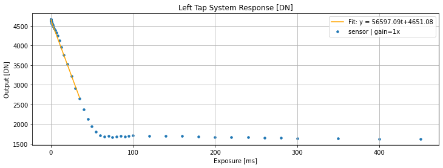

```python
fig = plt.figure(figsize=(12, 4))
plt.plot(
    exposures[:SAT]*1000,
    systemModel(exposures[:SAT], gain_dn_m[x,y], black_pt_m[x,y], SAT, fwc_m[x,y], tol1_m[x,y], tol2_m[x,y]),
    linestyle="-",
    label=r"Fit: y = {0:.2f}t+{1:.2f}".format(gain_dn_m[x,y], black_pt_m[x,y]),
    color='orange'
  )
plt.scatter(exposures*1000, avg_m[:,x,y], label="sensor | gain=1x", s=12)
plt.xlabel("Exposure [ms]")
plt.ylabel("Output [DN]")
plt.title("Left Tap System Response [DN]")
plt.legend()
plt.grid()
```

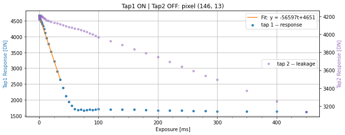

```python
fig, ax1 = plt.subplots(figsize=(10, 4))

color = 'tab:blue'
ax1.set_xlabel("Exposure [ms]")
ax1.set_ylabel("Tap1 Response [DN]", color=color)
ax1.scatter(exposures*1000, avg_m[:,x,y], color=color, s=16, alpha=0.9, label='tap 1 -- response')
ax1.plot(
    exposures[:SAT]*1000,
    systemModel(exposures[:SAT], gain_dn_m[x,y], black_pt_m[x,y], SAT, fwc_m[x,y], tol1_m[x,y], tol2_m[x,y]),
    linestyle="-",
    label=r"Fit: y = -{0:.0f}t+{1:.0f}".format(gain_dn_m[x,y], black_pt_m[x,y]+tol1_m[x,y]),
    color='tab:orange',
    alpha=1,
    linewidth=1.5
  )
major_ticks = np.arange(0, 501, 100)
minor_ticks = np.arange(0, 501, 25)

ax1.set_xticks(major_ticks)
ax1.set_xticks(minor_ticks, minor=True)
ax1.legend()
plt.grid(axis='both')

ax2 = ax1.twinx()  # instantiate a second axes that shares the same x-axis

color = 'tab:purple'
ax2.set_ylabel("Tap2 Response [DN]", color=color)  # we already handled the x-label with ax1
ax2.scatter(exposures*1000, avg_m[:,x,y+324], color=color, s=16, alpha=0.5, label='tap 2 -- leakage')

ax2.legend(loc=7)

plt.title("Tap1 ON | Tap2 OFF: pixel (%d, %d)" % (x,y))
fig.tight_layout()  # otherwise the right y-label is slightly clipped
plt.show()
```

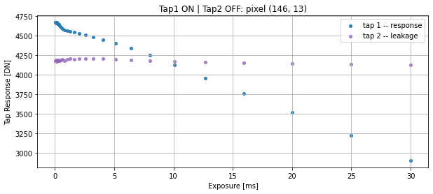

```python
fig, ax1 = plt.subplots(figsize=(10, 4))
plt.scatter(exposures[:32]*1000, avg_m[:32,x,y], color='tab:blue', s=16, alpha=0.9, label='tap 1 -- response')
plt.scatter(exposures[:32]*1000, avg_m[:32,x,y+324], color='tab:purple', s=16, alpha=0.8, label='tap 2 -- leakage')
plt.xlabel("Exposure [ms]")
plt.ylabel("Tap Response [DN]")
plt.grid()
plt.legend()
plt.title("Tap1 ON | Tap2 OFF: pixel (%d, %d)" % (x,y))
plt.show()
```

#### System Response -- Number of electrons

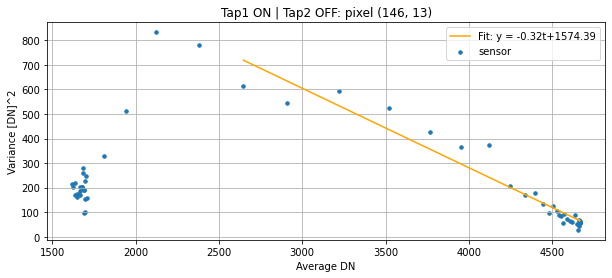

```python
fig = plt.figure(figsize=(10, 4))
plt.plot(avg_m[:SAT,x,y], -gain_conv_m[x,y]*avg_m[:SAT,x,y]+var_ns_m[x,y], linestyle="-", label=r"Fit: y = -{0:.2f}t+{1:.2f}".format(gain_conv_m[x,y],var_ns_m[x,y]), color='orange')
plt.scatter(avg_m[:,x,y], var_m[:,x,y], label="sensor", s=12)
plt.xlabel("Average DN")
plt.ylabel("Variance [DN]^2")
plt.title("Tap1 ON | Tap2 OFF: pixel (%d, %d)" % (x,y))
plt.legend()
plt.grid()
```

```python
1/gain_conv_m[x,y] # number of e- / DN
```

```
3.093031918546476
```

```python
np.sqrt(var_ns_m[x,y]) # read noise
```

```
39.67861
```